# Tutorial 7: Logistic Regression and Time Series Forecasting

Due by 25/03/2022 8:00 AM

## Submission Instructions

- Select `output: html_document`.
- Include all code chunks, so include `echo=TRUE` in all chunks.
- Replace the placeholder text, “Type your answer here.”, with your own.
- Submit *only* the required question for grading (Part 2: Submission). You can delete everything else for that submission. Remember to include any `library('package_name')` statements that you’ll need to run your code and future reproduction.
- Rename your R Markdown file `T[X]_[MatricNumber].rmd`, and the output will automatically be `T[X]_[MatricNumber].html`.
  - for example, `T6_12345.html`
  - X is the Tutorial number at the top of this file.
- Submit your both R Markdown file (.rmd) and HTML (.html) to for tutorial assignments (upload to Luminus under the correct Submission Folder). We shall do the same for practical exam.
- **It is important to be able to code and produce your Rmarkdown output file *independently*.** You are responsible for de-bugging and programming in the practical exam.

## Part Two: Assignment Submission (25 points)

### Question 3 (18 points)

We shall study women fertility rates with two time-series datasets on U.S. and Singapore, respectively.

High fertility rate is essential for long-term growth in any economy. Many countries are troubled low or even negative fertility rate. For example, the fertility rate in Singapore in general shows a decreasing trend in recent decades (https://www.channelnewsasia.com/news/singapore/number-of-babies-born-in-singapore-falls-to-lowest-in-8-years-11743722). Fertility is affected by many socio-economic factors, including single rate, family disposable income, level of tax duty, war attrition, contraception technology, etc.

Let’s first take a look at the fertility rate in the United States in 20th century. `fertil3` data contains information about woman’s fertility rate and personal tax exemption in U.S. in early-mid 1900s.

- Dataset required: `data('fertil3')` in `wooldridge` package.

(Note: This dataset comes from a publicly available dataset from Jeffery Wooldridge Textbook. See data description in https://rdrr.io/cran/wooldridge/man/fertil3.html)

First, load in the time series data for this question. There are 72 observations on 24 variables about women fertility rate between year 1913 and 1984. Key variables are listed below:

- `gfr`: births per 1000 women between age 15 and 44.
- `pe`: real value personal tax exemption in US dollars.
- `ww2`: a binary variable = 1 during World War 2 between 1941 and 1945.
- `pill`: a binary variable = 1 from 1963 on when the birth control pill was made available for contraception.

```r
# read dataset into workplace, note that you need library(wooldridge) to load this data set
data('fertil3')
# if you want, is can be converted to ts object
fertil = ts(fertil3, frequency = 1, start = 1913)
```

(3a) Start off by plotting `gfr` (fertility rate) and `pe` (personal tax exemption) against time in the same plot. What do you observe from the time series plots alone: do you see any trend or seasonality? Do you think that `gfr` time series is stationary? (2 points)

Remark: You should be able to visualize data with R base graphics at least. Other alternative R graphic packages such as `ggplot` are welcomed additions.

Both exhibit long-term trend. Between 1913 and 1938, gfr had a decreasing trend while pe had an increasing trend and from 1938 on, gfr and ge moved in the same direction with pe being more volatile.

gfr has a nonlinear trend and shows sign of autocorrelation (past values seem to be closely correlated with future values, apart from points where the trend reverses), thus likely seasonality.

Fertility Rate against Time: There is no consistent trend, since the fertility rate decreases, increases and decreases again, without an overall trend. There may be seasonality as the fertility rate repeats the pattern of decreasing and then increasing with a period of about 45 years. However, the seasonality is not confirmed since the time period given is too short to generalise seasonality patterns.

Personal Tax Exemption against Time: There is no overall trend, since the personal tax exemption increases then decreases. There is no seasonality since the graph does not repeat at certain lengths of intervals.

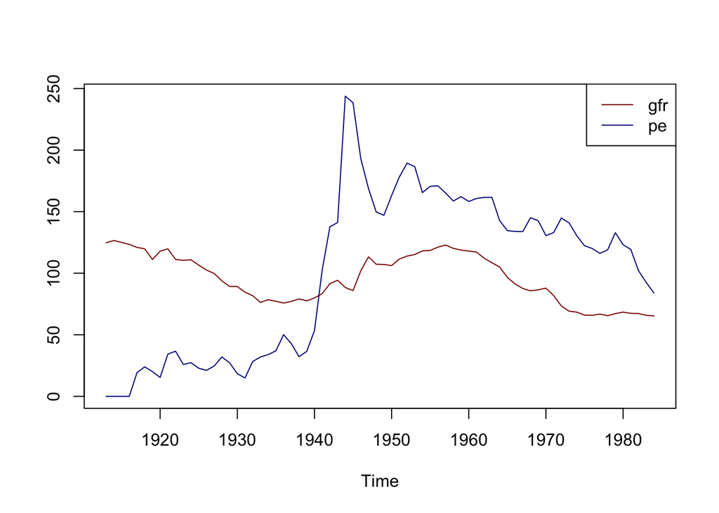

```r
# type your code here
ts.plot(fertil[, "gfr"],
        fertil[, "pe"],
        col=c("darkred","darkblue"))
legend("topright",
       legend=c("gfr","pe"),
       col=c("darkred","darkblue"),
       lty=1)
```

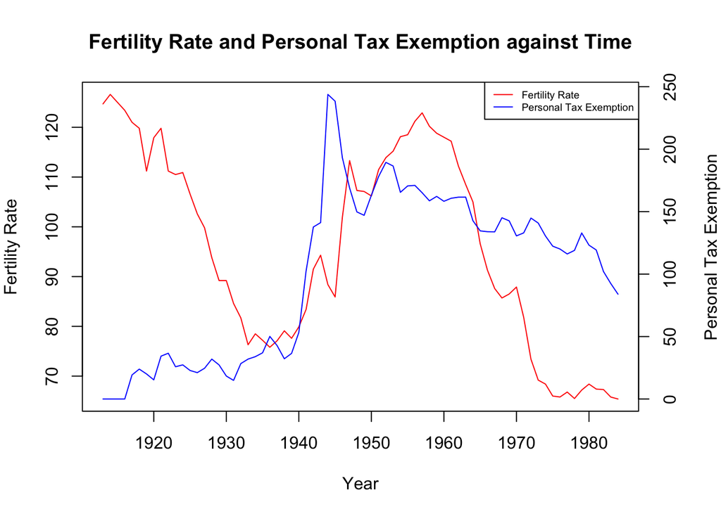

```r
par(mar = c(5, 4, 4, 4))
plot(fertil3$year,
     fertil3$gfr,
     type="l",
     col="red",
     ylab="Fertility Rate",
     xlab="Year")
par(new=TRUE)
plot(fertil3$pe,
     type="l",
     col="blue",
     axes=FALSE,
     xlab="",
     ylab="")
axis(side=4,
     at=pretty(range(fertil3$pe)))
mtext("Personal Tax Exemption",
      side = 4,
      line = 3)
legend("topright",
       cex=0.6,
       col=c("red", "blue"),
       lty=1,
       c("Fertility Rate", "Personal Tax Exemption"))
title("Fertility Rate and Personal Tax Exemption against Time")
```

(3b) If we want to study the relationship between personal tax exemption `pe` (an economic factor) and fertility rate `gfr`, run a linear regression of `gfr` on `pe`. Interpret the coefficient before `pe`. Is it statistically significant? What’s your conclusion about whether tax exemption improves fertility rate, from the regression output? (3 points)

There seems no relationship between fertility rate and tax exemption.

The intercept (b0) is 96.344294. This means that the average Fertility Rate is 96.344294 births per 1000 women if the Personal Tax Exemption is 0 US dollar. The t-value is large, and the p-value is small, less than 0.05, thus we can reject the null hypothesis that the intercept beta0 = 0, i.e., the intercept beta0 is statistically significant.

The coefficient before pe is -0.007095. This means that, on average, the when the Personal Tax Exemption increases by 1 US dollar, then we will expect to see the Fertility Rate on average decreases by 0.007095 birth per 1000 women (between age 15 and 44). The t-value is small, and the p-value of 0.844 is large, greater than 0.05, thus we fail to reject the null hypothesis that the slope beta1 = 0, i.e., the coefficient before pe is not statistically significant.

```r
# type your code here
model1 <- lm(gfr ~ pe, fertil)
summary(model1)
```

```
##
## Call:
## lm(formula = gfr ~ pe, data = fertil)
##
## Residuals:
##    Min     1Q Median     3Q    Max
## -30.35 -17.82  -1.68  18.34  30.26
##
## Coefficients:
##              Estimate Std. Error t value Pr(>|t|)
## (Intercept) 96.344294   4.304734  22.381   <2e-16 ***
## pe          -0.007095   0.035923  -0.198    0.844
## ---
## Signif. codes:  0 '***' 0.001 '**' 0.01 '*' 0.05 '.' 0.1 ' ' 1
##
## Residual standard error: 19.94 on 70 degrees of freedom
## Multiple R-squared:  0.000557,   Adjusted R-squared:  -0.01372
## F-statistic: 0.03901 on 1 and 70 DF,  p-value: 0.844
```

(3c) Now, include a time trend variable `t` into the regression model. Interpret the coefficient before `pe` and `t`. What’s been changed in the regression result compared to previous one? Which model do you think we should choose, and why? (4 points)

The sign flipped and the magnitude increased.

The R-squared value has increased significantly. The p-value has decreased significantly.

The intercept (b0) is now 109.93016, which has increased from the previous 96.344294. Now the intercept means that the average Fertility Rate is 109.93016 births per 1000 women if the Personal Tax Exemption is 0 US dollar. The t-value is large, and the p-value is small, less than 0.05, thus we can reject the null hypothesis that the intercept beta0 = 0, i.e., the intercept beta0 is statistically significant.

The coefficient before pe is now 0.18666, with the sign flipped and magnitude increased from the previous -0.007095. Now this coefficient means that, on average, when the Personal Tax Exemption increases by 1 US dollar, then we will expect to see the Fertility Rate on average increase by 0.18666 birth per 1000 women (between age 15 and 44). Now the t-value is large, and the p-value of 9.23e-07 is small, less than 0.05, thus we can reject the null hypothesis that the slope beta1 = 0, i.e., the coefficient before pe is statistically significant.

The second model should be chosen. It takes into consideration the time t, namely the patterns of fertility rate with respect to time. As observed from part 3a, it is likely that the model has seasonality patterns, i.e., the fertility rate changes with respect to time with a consistent pattern with fixed time intervals. Also, after taking time into consideration, the p-value of coefficient before pe becomes much smaller, now less than 0.05, indicating that the coefficient becomes statistically significant.

```r
# type your code here
model2 <- lm(gfr ~ pe + t, fertil)
summary(model2)
```

```
##
## Call:
## lm(formula = gfr ~ pe + t, data = fertil)
##
## Residuals:
##     Min      1Q  Median      3Q     Max
## -38.659  -9.934   1.841  11.027  22.882
##
## Coefficients:
##              Estimate Std. Error t value Pr(>|t|)
## (Intercept) 109.93016    3.47526  31.632  < 2e-16 ***
## pe            0.18666    0.03463   5.391 9.23e-07 ***
## t            -0.90519    0.10899  -8.305 5.53e-12 ***
## ---
## Signif. codes:  0 '***' 0.001 '**' 0.01 '*' 0.05 '.' 0.1 ' ' 1
##
## Residual standard error: 14.2 on 69 degrees of freedom
## Multiple R-squared:  0.5002, Adjusted R-squared:  0.4857
## F-statistic: 34.53 on 2 and 69 DF,  p-value: 4.064e-11
```

As we have discussed fertility rate in U.S. between 1913 and 1984 in previous question, now let’s turn our attention to fertility rate in Singapore in modern times, where the fertility rate plummets to lowest figure in 2020 in history.

- Dataset required: `SGfertil20.csv`

```r
# read raw data from 'sgfertil.csv'
sgfertil = read.csv(file = 'SGfertil20.csv', header= TRUE)
sgfertil = sgfertil %>%
  # given our focus in univariate time-series analysis on total fertility rate..
  select(Data.Series, Total.Fertility.Rate..Per.Female.) %>%
  # rename
  rename(year = Data.Series, gfr = Total.Fertility.Rate..Per.Female.) %>%
  # sort the data bt ascending on year
  arrange(year)
# extract the key time series of our interest and convert it to ts obj
gfrsg = ts(sgfertil$gfr, start = 1960, end = 2020, frequency = 1)
```

(3d) Let’s start off by plotting the `gfrsg` against time. Draw the time series plot of `gfrsg`. Describe what you observe from the plot: do you see any trend or/and seasonality? Do you think total fertility rate time series in Singapore `gfrsg` stationary? (2 points)

There is a general downward trend observed from the polt. With the passage of time, the Fertility Rate in Singapore generally decreases.

The total fertility rate time series in Singapore is not stationary as it generally decreases as time passes by. However, the fertility rate in Singapore indeed becomes stable with less decreasing trend towards the right of the graph, i.e. at later timings. The total fertility rate time series in Singapore becomes stationary towards the end.

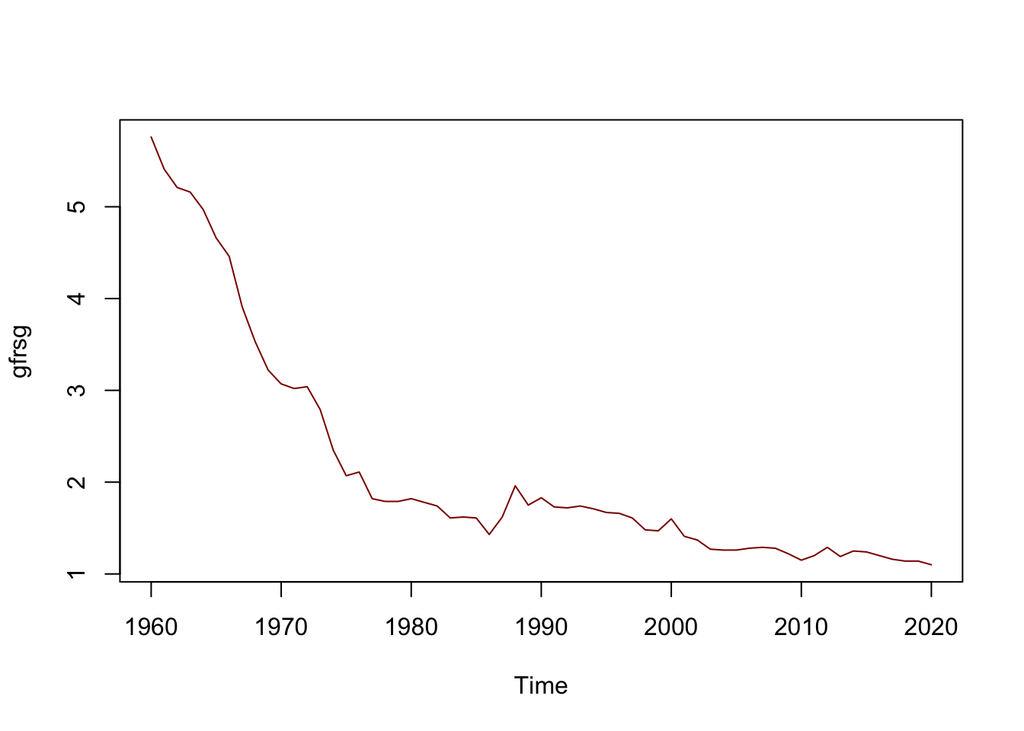

```r
# type your code here
plot.ts(gfrsg,
        col=("darkred"))
```

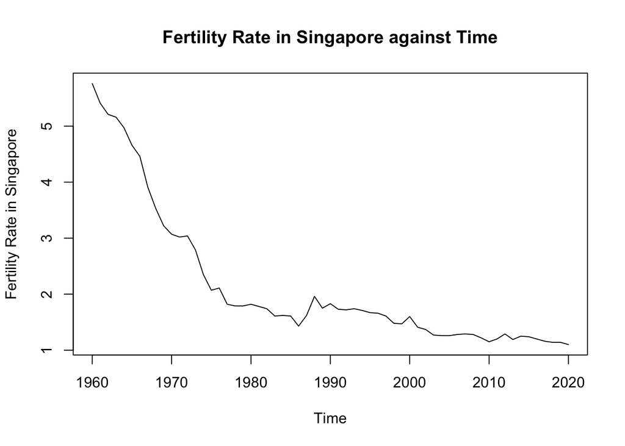

```r
plot(gfrsg,
     xlab="Time",
     ylab="Fertility Rate in Singapore")
title("Fertility Rate in Singapore against Time")
```

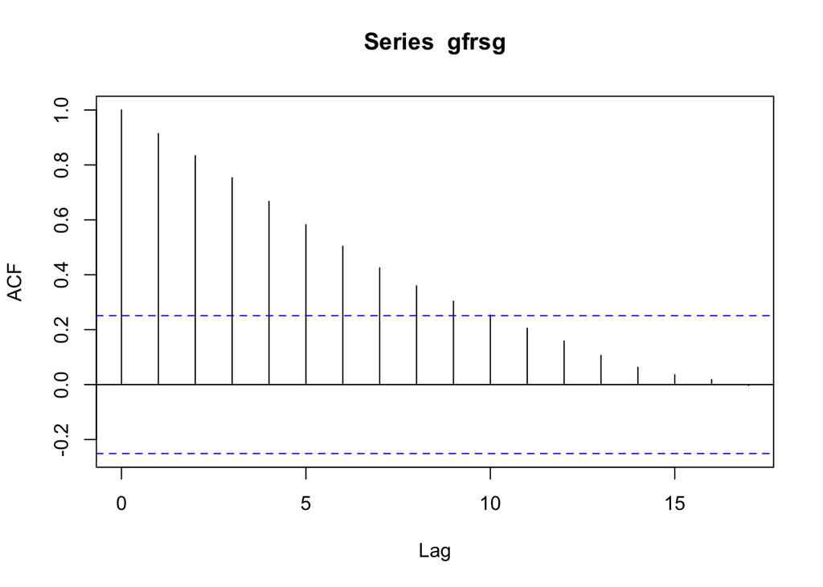

```r
acf(gfrsg)
```

(3e) In order to predict future fertility rate using information contained in the time series of `gfrsg` itself, let’s make forecast by simply fitting a moving average series. First, compute the moving averages with window length of 6 years and plot both the original and moving average series in the same graph. Second, obtain the moving average prediction series. What is the MA predicted value for Year 2021 and Year 2024? (4 points)

Typically we do not use moving average for future value predictions. It is generally used for visualisation purposes.

The MA predicted value for Year 2021 can be obtained by shifting the MA value for Year 2020 downwards by one year. The MA predicted value for Year 2024 can be obtained by shifting the MA value for 2020 downwards by four years. Both values are 1.163333.

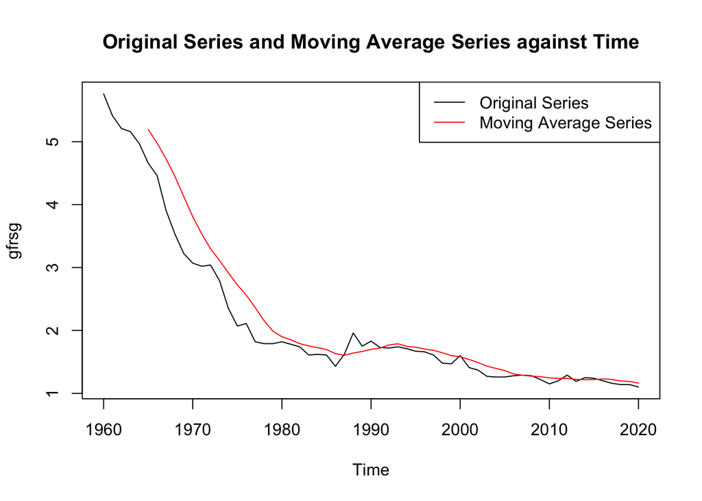

```r
# type your code here
gfrsg_ma6 = TTR::SMA(gfrsg, n=6)

plot(gfrsg)
lines(gfrsg_ma6,
      col="red")
legend("topright",
       cex=1,
       col=c("black", "red"),
       lty=1,
       c("Original Series", "Moving Average Series"))
title("Original Series and Moving Average Series against Time")
```

```r
gfrsg_ma6
```

```
## Time Series:
## Start = 1960
## End = 2020
## Frequency = 1
##  [1]       NA       NA       NA       NA       NA 5.195000 4.978333 4.728333
##  [9] 4.448333 4.125000 3.808333 3.535000 3.298333 3.111667 2.915000 2.723333
## [17] 2.563333 2.363333 2.155000 1.988333 1.900000 1.851667 1.790000 1.755000
## [25] 1.726667 1.696667 1.631667 1.605000 1.641667 1.665000 1.700000 1.720000
## [33] 1.768333 1.788333 1.746667 1.733333 1.705000 1.685000 1.645000 1.600000
## [41] 1.581667 1.538333 1.490000 1.433333 1.396667 1.361667 1.308333 1.288333
## [49] 1.273333 1.265000 1.246667 1.236667 1.238333 1.221667 1.216667 1.220000
## [57] 1.228333 1.221667 1.196667 1.188333 1.163333
```

```r
pre2021 <- gfrsg_ma6[61]
pre2021
```

```
## [1] 1.163333
```

```r
pre2024 <- gfrsg_ma6[61]
pre2024
```

```
## [1] 1.163333
```

(3f) Based on your observation in (Q3d), predict the fertility rates for Year 2021 and Year 2024 with Holt-Winter model of your choice. (3 points)

The predicted fertility rate for Year 2021 is 1.080670, and the predicted fertility rate for Year 2024 is 1.022681.

```r
# type your code here
model3 = HoltWinters(gfrsg, gamma=FALSE)
model3
```

```
## Holt-Winters exponential smoothing with trend and without seasonal component.
##
## Call:
## HoltWinters(x = gfrsg, gamma = FALSE)
##
## Smoothing parameters:
##  alpha: 1
##  beta : 0.2165719
##  gamma: FALSE
##
## Coefficients:
##          [,1]
## a  1.10000000
## b -0.01932966
```

```r
predict2024 <- predict(model3, n.ahead=4)
predict2024
```

```
## Time Series:
## Start = 2021
## End = 2024
## Frequency = 1
##           fit
## [1,] 1.080670
## [2,] 1.061341
## [3,] 1.042011
## [4,] 1.022681
```

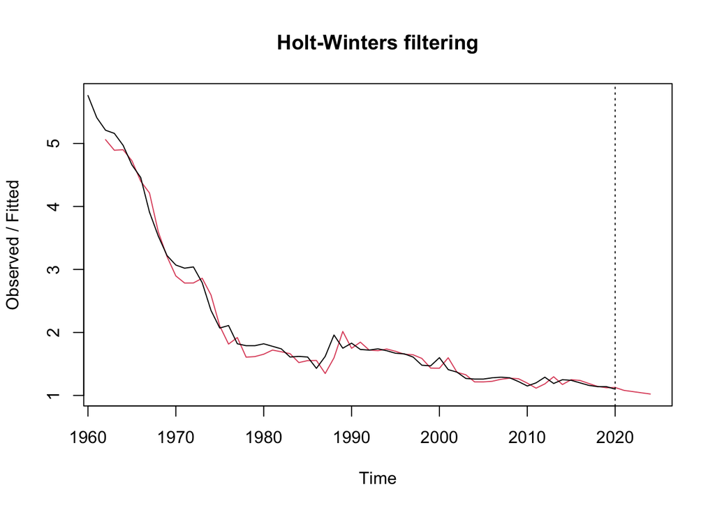

```r
plot(model3, predict2024)
```

### Question 4 (7 points)

- Dataset required: `data('recid')`

We shall continue with the `recid` problem from the previous tutorial and examine the the likelihood of supervised release, where an offender is released from prison subject to monitoring and supervision of probation officer. A reminder of the dataset we had:

```r
recid = read.csv(file = 'recid.csv', header= TRUE)
```

C.-F. Chung, P. Schmidt, and A.D. Witte (1991), “Survival Analysis: A Survey,” Journal of Quantitative Criminology 7, 59-98. Data Source: https://www.cengage.com/cgi-wadsworth/course_products_wp.pl?fid=M20b&product_isbn_issn=9781111531041. A quick description of the data:

Obs: 1445

1. black =1 if black
2. alcohol =1 if alcohol problems
3. drugs =1 if drug history
4. super =1 if release supervised
5. married =1 if married when incarc.
6. felon =1 if felony sentence
7. workprg =1 if in N.C. pris. work prg.
8. property =1 if property crime
9. person =1 if crime against person
10. priors # prior convictions
11. educ years of schooling
12. rules # rules violations in prison
13. age in months
14. tserved time served, rounded to months
15. follow length follow period, months
16. durat max(time until return, follow) in month
17. cens =1 if duration right censored
18. ldurat log(durat)

(4a) Criminal offense lawyers usually fight for supervised release of the offender. Given five variables in `recid` data set: `super`, `rules`, `age`, `tserved`, `married`, and `black`, how could you help the law firm to predict the outcome of a recent case given that a 46-year-old married non-black client has been serving the jail time for 3 years and 7 months and during which broken no rule in the prison? In order to evaluate the likelihood to answer such question. First of all, write down the regression model you propose to use. Clearly define or label your variables. (2 point)

$$logit(p) = log(p/(1-p)) + \beta_0 + \beta_1 * X_1 + \beta_2 * X_2 + \beta_3 * X_3 + \beta_4 * X_4 + \beta_5 * X_5 + \epsilon$$

p is the probability of a successful supervised release. X1 is the rules violations in prison `rules`. X2 is the age of the criminal in months `age`. X3 is the time served rounded to months `tserved`. X4 is the marriage status `married` with 1 if married and 0 otherwise. X5 is the race of the criminal `black` with 1 if black and 0 if otherwise.

(4b) Run your regression model in R and interpret the coefficients before `rules` and `black`. Based on the results, do you think there was any racial discrimination in terms of likelihood of supervised release, and why? (3 point)

The coefficient before rules is -0.2440268. Breaking each rule in prison on average decreases the log-odds of successful supervised release by 0.2440268, holding all other variables constant. By breaking one additional rule in prison, on average, the odds of successful supervised release is multiplied by exp(-0.2440268) = 0.7834666371, i.e., the odds of successful supervised release decreases by 21.7%. The z-value is large and the p-value is small, less than 0.05, thus we can reject the null hypothesis that this slope beta1 = 0, i.e., the coefficient before rules is statistically significant.

The coefficient before black is 0.1132077. Being of black race on average increases the log-odds of successful supervised release by 0.1132077, holding all other variables constant. Being of the black race multiplies the odds of successful supervised release by exp(0.1132077) = 1.119864505, i.e., the odds of successful supervised release increases by 12.0%. However, the z-value is small and the p-value is large, greater than 0.05, thus we cannot reject the null hypothesis that this slope beta5 = 0, i.e., the coefficient before black is not statistically significant.

I do not think there was any racial discrinimation in terms of likelihood of supervised release, since the coefficient before black is not statistically significant in determining the odds of successful supervised release.

```r
# type your code here
model4 = glm(super ~ rules + age + tserved + married + black,
             family = binomial,
             data = recid)
summary(model4)
```

```
##
## Call:
## glm(formula = super ~ rules + age + tserved + married + black,
##     family = binomial, data = recid)
##
## Deviance Residuals:
##     Min       1Q   Median       3Q      Max
## -2.9171  -1.2826   0.7302   0.8673   1.9883
##
## Coefficients:
##               Estimate Std. Error z value Pr(>|z|)
## (Intercept)  1.0144454  0.1965122   5.162 2.44e-07 ***
## rules       -0.2440268  0.0359240  -6.793 1.10e-11 ***
## age         -0.0018470  0.0004914  -3.759 0.000171 ***
## tserved      0.0319665  0.0048895   6.538 6.25e-11 ***
## married      0.5115352  0.1458073   3.508 0.000451 ***
## black        0.1132077  0.1189016   0.952 0.341040
## ---
## Signif. codes:  0 '***' 0.001 '**' 0.01 '*' 0.05 '.' 0.1 ' ' 1
##
## (Dispersion parameter for binomial family taken to be 1)
##
##     Null deviance: 1779.6  on 1444  degrees of freedom
## Residual deviance: 1687.6  on 1439  degrees of freedom
## AIC: 1699.6
##
## Number of Fisher Scoring iterations: 4
```

(4c) Finally, what is the predicted probability for supervised release for the new client? (2 point)

Note: Classify a successful supervised release case if probability of supervised release is greater or equal to 0.5; and no supervised release otherwise.

```r
# type your code here
to.predict <- data.frame(rules=0, age=46*12, tserved=3*12+7, married=1, black=0)
pre = predict(model4, newdata=to.predict, type="response")
pre
```

```
##         1
## 0.8677237
```

```r
exp(pre)
```

```
##        1
## 2.381484
```

```r
exp(pre)/(1+exp(pre))
```

```
##         1
## 0.7042718
```